# Traitement des données de la BDAT

Jean-Baptiste Paroissien

21/12/2016

```r
Sys.Date()
```

```
[1] "2017-01-10"
```

# 1 Objectifs

Ce fichier de suivi a pour but de centraliser l’ensemble des analyses des teneurs en carbone organique de la BDAT. Ce travail est organisé de la façon suivante :

- Analyse des histogrammes de fréquence et tests statistiques pour chacune des périodes de temps analysées,
- Représentation cartographique par canton,
- Analyse des facteurs explicatifs.

# 2 Préparation des données et chargement de la table de travail

## 2.1 Préparation

Les données de la BDAT sont ré-organisées pour faciliter les traitements statistiques et la production de graphiques. La fonction `melt` est utilisée pour transformer les données d’un format “large” à un format “long”. En complément, les évolutions des teneurs pour les différentes périodes analysées sont calculées.

```r
# Paramètres
dsn <- "PG:dbname='sol_elevage' host='localhost' port='5432' user='jb'" # Configuration de la connexion vers le PostGIS
table_dm <- "dm_vecteurs.canton" # Nom de la table pour rassembler les calculs (vers le schéma dm_vecteurs)
period <- c("9094","9599","0004","0509","1014")
schema <- "bdat"

for(i in period){
  var_variable <- paste("corgox_medequi",i,sep="")
  tableBDAT <- paste("bdat_canton_corgequiv",i,sep="")

  sqlQuery(loc,paste("alter table ",table_dm,"
                      drop column if exists ",var_variable,sep=""))

  sqlQuery(loc,paste("alter table ",table_dm,"
                      add column ",var_variable," numeric;
                      update ",table_dm,"
                      SET ",var_variable," = s1.med from(
                      select med,canton
                      from ",schema,".",tableBDAT,") as s1
                      where ",table_dm,".code_canton=s1.canton::text",sep=""))

  # Ajout d'un commentaire sur la nouvelle colonne crée
  print(sqlQuery(loc,paste("
  COMMENT ON COLUMN ",table_dm,".",var_variable," IS \'Médiane des teneurs en carbone organique après ré-échantillonnage pour la période ",i,".\';",sep="")))
}
```

Pour la création de cette table, prendre en compte le fait qu’il faille lancer d’autres scripts avant. Il faudra peut être revoir l’organisation des scripts pour éviter ce genre de désagrément.

```r
# Paramètres
dsn <- "PG:dbname='sol_elevage' host='localhost' port='5432' user='jb'" # Configuration de la connexion vers le PostGIS
table_dm <- "dm_vecteurs.canton" # Nom de la table pour rassembler les calculs (vers le schéma dm_vecteurs)
varia <- c("corgox_medequi") # Variable à analyser
period <- c("9094","9599","0004","0509","1014")
mapcanton <- readOGR(dsn = dsn, "dm_vecteurs.canton")
id <- c("code_canton","code_reg","nom_region","typo_clim","zonage_simple","zonage_cplt") #Nom de l'identifiant

# Boucle pour séparer l'année du nom de la variable étudiée
cpt <- 0
for(i in varia){
  print(i)
  cpt <- cpt + 1
  variaperiod <- paste(i,period,sep="")

  stats.canton <- mapcanton[,c(id,variaperiod)]
  # Modification de la structure de la table
  stats.canton <- melt(data=stats.canton@data,id.vars=id)
  # Extraction de l'année et renommage des colonnes
  stats.canton[,"variable"] <- as.character(unlist(regmatches(stats.canton[,"variable"],gregexpr('[0-9]+.[0-9]+',stats.canton[,"variable"]))))
  colnames(stats.canton)[(length(id)+1):(length(id)+2)] <- c("annees",i) #revoir la sélection de ces colonnes

  if(cpt==1){
    # Construction de la première table
    melt.canton <- stats.canton
  }else{
    # Ajout à chaque itération de la variable (i)
    melt.canton <- merge(melt.canton,stats.canton, by.x=c(id,"annees"), by.y=c(id,"annees"),all.x=TRUE,all.y=TRUE)
  }
}

# Création finale de la table
melted.bdat <- melt(data=melt.canton,id.vars=c(id,"annees"))
melted.bdat$annees <- as.character(melted.bdat$annees)
melted.bdat$typo_clim <- as.factor(melted.bdat$typo_clim)

# Enregistrement dans le schema dm_traitements
tablename <- paste("dm_traitements.","melted_bdat",sep="")
sqlQuery(loc,paste("drop table if exists ",tablename,sep=""))
sqlSave(loc,melted.bdat,tablename=tablename)
```

## 2.2 Chargement des données et des principaux paramètres d’étude

# 3 Analyse des teneurs en carbone organique par période

## 3.1 Statistiques descriptives et courbes de fréquences cumulées

### 3.1.1 France entière et par type de climat

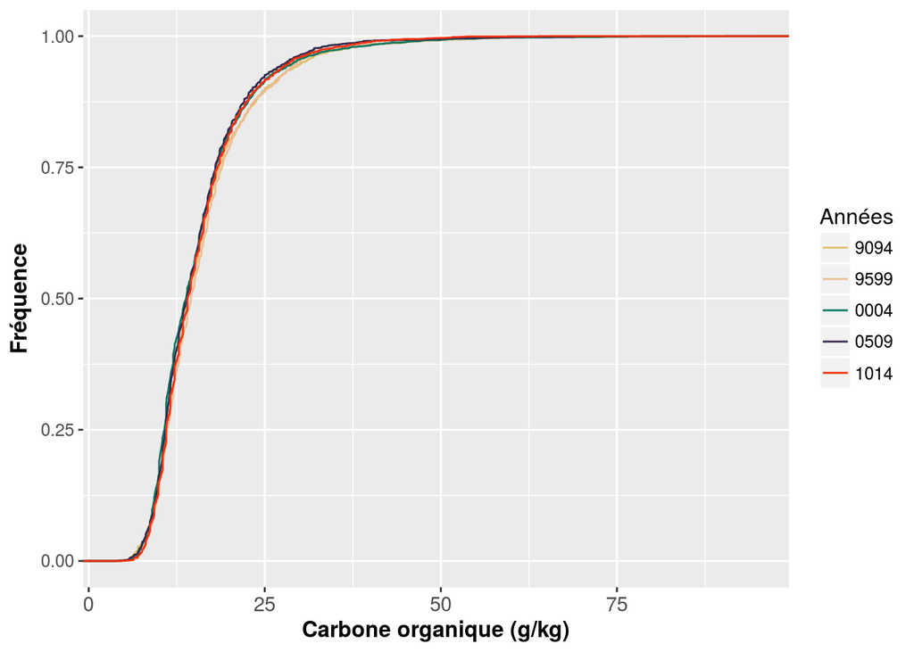

Faire un commentaire par type de climat

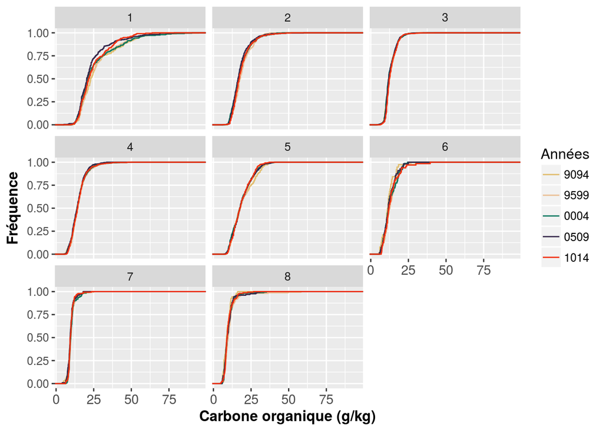

Test également en fonction des différentes régions d’élevage

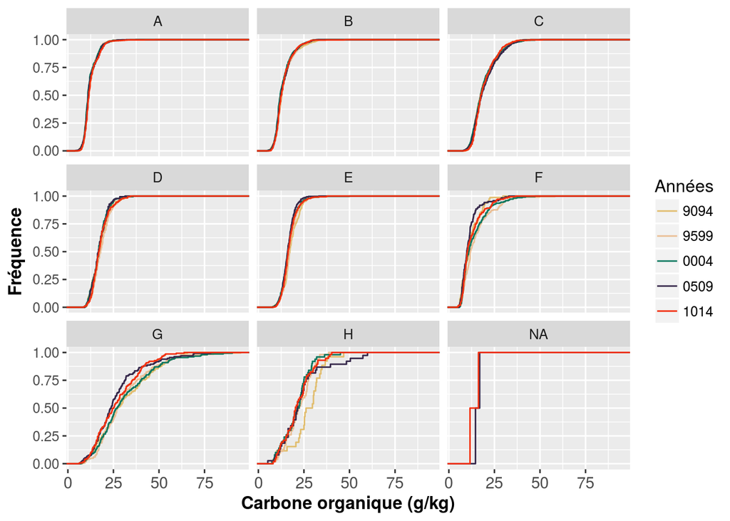

## 3.2 Statistiques descriptives

### 3.2.1 Tableaux

Les statistiques par années sont présentées dans le tableau ci-dessous

```r
# Résumé des statistiques
bdatsummary <- apply(melted.bdat["value"],2, function(x) tapply(x, melted.bdat[,"annees"],summary))
bdatsummary <- lapply(bdatsummary, do.call, what = rbind)

pander(bdatsummary[[1]],caption = "Statistiques descriptives par période des teneurs en CO pour la France entière")
```

Statistiques descriptives par période des teneurs en CO pour la France entière

|  | Min. | 1st Qu. | Median | Mean | 3rd Qu. | Max. | NA’s |
| --- | --- | --- | --- | --- | --- | --- | --- |
| **9094** | 4.58 | 11.04 | 14.07 | 16.03 | 18.52 | 65.58 | 1381 |
| **9599** | 5.23 | 11.15 | 14.53 | 16.27 | 18.92 | 94.85 | 740 |
| **0004** | 4.6 | 10.76 | 13.81 | 15.61 | 18.02 | 90.23 | 737 |
| **0509** | 3.78 | 10.91 | 13.96 | 15.44 | 18 | 78.37 | 956 |
| **1014** | 4.7 | 11 | 14.02 | 15.71 | 18.3 | 63.75 | 748 |

# 4 Résumé des statistiques

```r
# Ici, voir pour rajouter année+zonage_simple ou année+climato ou année+région
bdatsummary2 <- apply(melted.bdat["value"],2, function(x) tapply(x, list(melted.bdat[,"zonage_simple"],melted.bdat[,"annees"]),summary))
bdatsummary2 <- data.frame(bdatsummary2[[1]])
bdatsummary2 <- lapply(bdatsummary2, do.call, what = rbind)
names(bdatsummary2) <- period

pander(bdatsummary2,caption = "Statistiques descriptives par période des teneurs en CO pour les principales régions d'élevage")
```

- **9094**:

  |  | Min. | 1st Qu. | Median | Mean | 3rd Qu. | Max. | NA’s |
  | --- | --- | --- | --- | --- | --- | --- | --- |
  | **A** | 4.58 | 9.88 | 11.33 | 12.32 | 14.1 | 34.13 | 388 |
  | **B** | 4.89 | 10.56 | 12.89 | 14.1 | 16.1 | 36.4 | 197 |
  | **C** | 9.3 | 14.15 | 17.44 | 19.24 | 23.5 | 41.1 | 128 |
  | **D** | 9.3 | 13.85 | 17 | 17.69 | 20.76 | 31.57 | 113 |
  | **E** | 6.8 | 15.37 | 17.27 | 17.84 | 20.45 | 36.82 | 100 |
  | **F** | 5 | 7.835 | 11.14 | 11.83 | 14.08 | 29.65 | 219 |
  | **G** | 7.85 | 18.76 | 27.28 | 30.81 | 40.56 | 65.58 | 117 |
  | **H** | 8 | 22.81 | 27.9 | 26.9 | 31.91 | 46.8 | 117 |

- **9599**:

  |  | Min. | 1st Qu. | Median | Mean | 3rd Qu. | Max. | NA’s |
  | --- | --- | --- | --- | --- | --- | --- | --- |
  | **A** | 5.35 | 9.88 | 11.48 | 12.3 | 14 | 36.99 | 284 |
  | **B** | 5.5 | 10.78 | 12.85 | 14.04 | 16.28 | 32.56 | 85 |
  | **C** | 8.72 | 14.78 | 17.97 | 19.42 | 23 | 41.72 | 53 |
  | **D** | 8.95 | 15.03 | 17.92 | 18.4 | 21.39 | 35.26 | 25 |
  | **E** | 8.04 | 14.86 | 17 | 17.33 | 19.77 | 34 | 58 |
  | **F** | 5.23 | 9.025 | 11.83 | 14.75 | 17.44 | 58.2 | 80 |
  | **G** | 8 | 19.8 | 27 | 30.66 | 37.89 | 94.85 | 64 |
  | **H** | 7.56 | 17.14 | 22.31 | 22.35 | 27.34 | 38.51 | 89 |

- **0004**:

  |  | Min. | 1st Qu. | Median | Mean | 3rd Qu. | Max. | NA’s |
  | --- | --- | --- | --- | --- | --- | --- | --- |
  | **A** | 5.2 | 9.8 | 11 | 12.08 | 13.55 | 37.2 | 253 |
  | **B** | 4.6 | 10.21 | 12 | 13.44 | 15.55 | 32.6 | 95 |
  | **C** | 7.54 | 14.43 | 17.4 | 19.23 | 22.78 | 50 | 49 |
  | **D** | 9.36 | 13.93 | 16.8 | 17.15 | 19.58 | 35.84 | 16 |
  | **E** | 7.79 | 13.88 | 16.25 | 16.68 | 18.6 | 50 | 57 |
  | **F** | 5.9 | 8.4 | 10.88 | 13.66 | 16.74 | 47.33 | 79 |
  | **G** | 7.35 | 19.49 | 26.93 | 30.99 | 40.02 | 90.23 | 93 |
  | **H** | 7.46 | 15.51 | 21.76 | 20.94 | 24.97 | 45.04 | 93 |

- **0509**:

  |  | Min. | 1st Qu. | Median | Mean | 3rd Qu. | Max. | NA’s |
  | --- | --- | --- | --- | --- | --- | --- | --- |
  | **A** | 3.78 | 9.9 | 11.16 | 12.27 | 14.02 | 32 | 273 |
  | **B** | 5.58 | 10.5 | 12.33 | 13.73 | 16.11 | 31.82 | 127 |
  | **C** | 7.83 | 14.5 | 18 | 19.78 | 23.8 | 44.74 | 65 |
  | **D** | 9.3 | 14.1 | 16.84 | 17.19 | 19.82 | 31.32 | 15 |
  | **E** | 7.8 | 13.97 | 16.05 | 16.31 | 18.31 | 33.1 | 80 |
  | **F** | 5.54 | 7.95 | 9.84 | 11.16 | 12.3 | 32.88 | 177 |
  | **G** | 6.51 | 16.9 | 23.7 | 26.54 | 31.25 | 78.37 | 114 |
  | **H** | 5.18 | 16.3 | 21.5 | 23.75 | 26.04 | 59.9 | 105 |

- **1014**:

  |  | Min. | 1st Qu. | Median | Mean | 3rd Qu. | Max. | NA’s |
  | --- | --- | --- | --- | --- | --- | --- | --- |
  | **A** | 5.75 | 10.05 | 11.6 | 12.64 | 14 | 47.82 | 214 |
  | **B** | 6.4 | 10.88 | 12.54 | 13.88 | 15.91 | 47.95 | 94 |
  | **C** | 8.39 | 15.1 | 17.45 | 19.48 | 22.7 | 51.47 | 39 |
  | **D** | 8.7 | 14.5 | 17 | 17.79 | 20.3 | 34.3 | 14 |
  | **E** | 8.4 | 14.5 | 16.3 | 17.03 | 19.02 | 37.81 | 83 |
  | **F** | 4.7 | 8.522 | 10.18 | 12.53 | 14.83 | 36.57 | 122 |
  | **G** | 6.25 | 16.8 | 25 | 26.93 | 35.36 | 63.75 | 96 |
  | **H** | 8.1 | 15.7 | 20.35 | 21.47 | 26.07 | 40.27 | 86 |

```r
melted.bdat <- melted.bdat[complete.cases(melted.bdat),]
# avec ddply
test3 <- ddply(melted.bdat, c("annees", "zonage_simple"), summarise,
      Min=min(value,na.rm=TRUE),
      st_Qu=quantile(value,0.25,na.rm=TRUE),
      Median=median(value,na.rm=TRUE),
      Mean=mean(value,na.rm=TRUE),
      rd_Qu=quantile(value,0.75,na.rm=TRUE),
      Max=max(value,na.rm=TRUE),
      nbr=length(value))

pander(test3,caption = "Statistiques descriptives par période des teneurs en CO pour les principales régions d'élevage")
```

Statistiques descriptives par période des teneurs en CO pour les principales régions d’élevage

| annees | zonage_simple | Min | st_Qu | Median | Mean | rd_Qu | Max | nbr |
| --- | --- | --- | --- | --- | --- | --- | --- | --- |
| 9094 | A | 4.58 | 9.88 | 11.33 | 12.32 | 14.1 | 34.13 | 657 |
| 9094 | B | 4.89 | 10.56 | 12.89 | 14.1 | 16.1 | 36.4 | 634 |
| 9094 | C | 9.3 | 14.15 | 17.44 | 19.24 | 23.5 | 41.1 | 345 |
| 9094 | D | 9.3 | 13.85 | 17 | 17.69 | 20.77 | 31.57 | 82 |
| 9094 | E | 6.8 | 15.37 | 17.27 | 17.84 | 20.45 | 36.82 | 306 |
| 9094 | F | 5 | 7.835 | 11.14 | 11.83 | 14.09 | 29.65 | 79 |
| 9094 | G | 7.85 | 18.75 | 27.28 | 30.81 | 40.55 | 65.58 | 130 |
| 9094 | H | 8 | 22.81 | 27.91 | 26.9 | 31.91 | 46.8 | 26 |
| 9599 | A | 5.35 | 9.88 | 11.48 | 12.3 | 14 | 36.99 | 761 |
| 9599 | B | 5.5 | 10.78 | 12.85 | 14.04 | 16.28 | 32.56 | 746 |
| 9599 | C | 8.72 | 14.79 | 17.97 | 19.42 | 23 | 41.72 | 420 |
| 9599 | D | 8.95 | 15.03 | 17.92 | 18.4 | 21.39 | 35.26 | 170 |
| 9599 | E | 8.04 | 14.86 | 17 | 17.33 | 19.77 | 34 | 348 |
| 9599 | F | 5.23 | 9.025 | 11.83 | 14.75 | 17.44 | 58.2 | 218 |
| 9599 | G | 8 | 19.8 | 27 | 30.66 | 37.89 | 94.85 | 183 |
| 9599 | H | 7.56 | 17.14 | 22.31 | 22.35 | 27.34 | 38.51 | 54 |
| 0004 | A | 5.2 | 9.8 | 11 | 12.08 | 13.55 | 37.2 | 792 |
| 0004 | B | 4.6 | 10.21 | 12 | 13.44 | 15.55 | 32.6 | 736 |
| 0004 | C | 7.54 | 14.43 | 17.39 | 19.23 | 22.79 | 50 | 424 |
| 0004 | D | 9.36 | 13.93 | 16.8 | 17.15 | 19.57 | 35.84 | 179 |
| 0004 | E | 7.79 | 13.88 | 16.25 | 16.68 | 18.6 | 50 | 349 |
| 0004 | F | 5.9 | 8.4 | 10.88 | 13.66 | 16.73 | 47.33 | 219 |
| 0004 | G | 7.35 | 19.49 | 26.93 | 30.99 | 40.02 | 90.23 | 154 |
| 0004 | H | 7.46 | 15.51 | 21.76 | 20.94 | 24.97 | 45.04 | 50 |
| 0509 | A | 3.78 | 9.9 | 11.16 | 12.27 | 14.03 | 32 | 772 |
| 0509 | B | 5.58 | 10.5 | 12.33 | 13.73 | 16.11 | 31.82 | 704 |
| 0509 | C | 7.83 | 14.5 | 18 | 19.78 | 23.8 | 44.74 | 408 |
| 0509 | D | 9.3 | 14.1 | 16.84 | 17.19 | 19.82 | 31.32 | 180 |
| 0509 | E | 7.8 | 13.97 | 16.05 | 16.31 | 18.31 | 33.1 | 326 |
| 0509 | F | 5.54 | 7.95 | 9.84 | 11.16 | 12.3 | 32.88 | 121 |
| 0509 | G | 6.51 | 16.9 | 23.7 | 26.54 | 31.25 | 78.37 | 133 |
| 0509 | H | 5.18 | 16.3 | 21.5 | 23.75 | 26.04 | 59.9 | 38 |
| 1014 | A | 5.75 | 10.05 | 11.6 | 12.64 | 14 | 47.82 | 831 |
| 1014 | B | 6.4 | 10.88 | 12.54 | 13.88 | 15.91 | 47.95 | 737 |
| 1014 | C | 8.39 | 15.1 | 17.45 | 19.48 | 22.7 | 51.47 | 434 |
| 1014 | D | 8.7 | 14.5 | 17 | 17.79 | 20.3 | 34.3 | 181 |
| 1014 | E | 8.4 | 14.5 | 16.3 | 17.03 | 19.02 | 37.81 | 323 |
| 1014 | F | 4.7 | 8.522 | 10.18 | 12.53 | 14.83 | 36.57 | 176 |
| 1014 | G | 6.25 | 16.8 | 25 | 26.93 | 35.36 | 63.75 | 151 |
| 1014 | H | 8.1 | 15.7 | 20.35 | 21.47 | 26.07 | 40.27 | 57 |